# Zeta Function: Functional Equation and Analytical Continuation

### **NOTES ON STATISTICS, PROBABILITY and MATHEMATICS**

As a preamble, there are three terms that recur:

1. Analytical continuation: In complex analysis analytic continuation is a technique to extend the domain of definition of a given analytic function. Analytic continuation often succeeds in defining further values of a function, for example in a new region where the infinite series representation which initially defined the function becomes divergent. ([source](https://en.wikipedia.org/wiki/Analytic_continuation)).
2. [Functional equation](https://en.wikipedia.org/wiki/Functional_equation#:~:text=In%20mathematics%2C%20a%20functional%20equation,integral%20equations%20are%20functional%20equations.)
3. [L-functions](https://en.wikipedia.org/wiki/L-function): An L-function is a meromorphic function on the complex plane, resulting from analytical continuation of an L-series (Dirichlet series).
4. [Dirichlet series](https://en.wikipedia.org/wiki/Dirichlet_series): A complex sequence of the form

$$\mathcal D(s) = \sum_{n=1}^\infty
\frac{a_n}{n^s}$$

### Derivation of the Functional Equation of the Zeta Function:

From [here](https://youtu.be/epmnnJSrDCY?si=3T0KsqTBoueZQl0N) and [here](https://en.wikipedia.org/wiki/Riemann_zeta_function#:~:text=The%20functional%20equation%20was%20established%20by%20Riemann,Magnitude%22%20and%20used%20to%20construct%20the%20analytic):

Start witht the gamma function:

$$\Gamma(s) = \int_{0}^\infty e^{-t} \,
t^{s-1} \, dt$$

Consider instead $s/2$:

$$\Gamma\left(\frac s 2\right) =
\int_{0}^\infty e^{-t} \, t^{\frac s 2-1} \, dt$$

Why? So that the denominator in $(\cdot)^{\frac s 2}$ cancels out the $2$ in $n^2$ in the substitution that follows in the next line:

Let $t = \pi n^2 x,$

$$\Gamma\left(\frac s 2\right)=
\int_{0}^\infty e^{-\pi n^2 x} \, (\pi n^2 x)^{\frac s 2 -1} \, \pi
n^2 dx$$

Why? To later use the [Jacobi theta function](https://mathworld.wolfram.com/JacobiThetaFunctions.html).

Taking out terms:

$$\Gamma\left(\frac s 2\right) =
\pi^{\frac s2}\, n^s \int_{0}^\infty e^{-\pi n^2 x} \, x^{\frac s 2-1}
\, dx$$

Rearranging,

$$\frac{\Gamma\left(\frac s
2\right)\,\pi^{-\frac s 2}}{n^s} = \int_{0}^\infty e^{-\pi n^2 x} \,
x^{\frac s 2-1} \, dx$$

Summing on both sides:

$$\sum_{n=1}^\infty
\frac{\Gamma\left(\frac s 2\right)\,\pi^{-\frac s 2}}{n^s} =
\sum_{n=1}^\infty \int_{0}^\infty e^{-\pi n^2 x} \, x^{\frac s 2-1} \,
dx$$
and rearranging:

$$\Gamma\left(\frac s
2\right)\,\pi^{-s/2} \sum_{n=1}^\infty \frac 1{n^s} = \int_{0}^\infty
\sum_{n=1}^\infty e^{-\pi n^2 x} \, x^{s/2-1} \, dx$$
Or

$$\Gamma\left(\frac s
2\right)\,\pi^{-\frac s 2} \, \zeta(s) = \int_{0}^\infty \, x^{\frac s
2-1} \, \color{red}{\sum_{n=1}^\infty e^{-\pi n^2 x} } \,
dx$$

Observe the similarity between the expression in red and the Jacobi theta function:

$$\Theta(x)=\sum_{n=-\infty}^\infty
e^{-\pi n^2 x}$$

By symmetry of an even function,

$$\Theta(x)=\sum_{n=-\infty}^{-1} e^{-\pi
n^2 x} + 1 + \sum_{n=1}^{\infty} e^{-\pi n^2 x}= 1 + 2 \,
\sum_{n=1}^{\infty} e^{-\pi n^2 x}=1 + 2 \,\color{red}{\psi(x)}$$
We can split the initial equation as

$$\Gamma\left(\frac s
2\right)\,\pi^{-\frac s 2} \, \zeta(s) = \int_{0}^\infty \, x^{\frac s
2-1} \, \psi(x) \, dx= \int_{0}^1 \, x^{\frac s 2-1} \, \psi(x) \, dx +
\int_{1}^\infty \, x^{\frac s 2-1} \, \psi(x) \, dx= I_1 +
I_2$$

Evaluating $I_1,$ and letting $x = 1/t,$ which means that $dx = - \frac{dt}{t^2}$:

$$I_1 =\int_{0}^1 \, x^{\frac s 2-1} \,
\psi(x) \, dx=\int_{\infty}^1- \, \left(\frac 1 t \right)^{\frac s 2-1}
\, \psi\left(\frac 1 t\right) \, \frac{dt}{t^2} = \int_{1}^\infty \,
\left(\frac 1 t \right)^{-\frac s 2-1} \, \color{orange}{\psi\left(\frac
1 t\right)} \, dt$$

Because of the property of the Jacobi $\Theta$ that says that $\theta(x)=1/\sqrt x \, \Theta(1/x),$

$$(1+ 2 \psi(x))= \frac 1 {\sqrt x}\left(1
+ 2 \psi\left(\frac 1 x\right)\right)$$

and therefore,

$$\color{orange}{\psi\left(\frac 1
x\right)=\frac{\sqrt x}{2} + \sqrt x \, \psi(x) - 1/2}$$

so plugging this back into the orange expression in $I_1:$

$$I_1 = \frac 1 2 \int_{1}^{\infty}
t^{\frac 1 2 - \frac s 2-1} dt + \int_{1}^{\infty}t^{\frac 1 2 - \frac s
2-1}\,\psi(t) \, dt - \frac 1 2 \int_{1}^{\infty}t^{ - \frac s 2-1}
dt$$

Evaluating the first and third integrals,

$$I_1 = -\frac{1}{1 - s}- \frac 1 s +
\int_1^\infty t^{-\frac s 2-\frac 1 2}\,\psi(t)\,dt = \int_1^\infty
x^{-\frac s 2-\frac 1 2}\,\psi(x)\,dx-\frac 1 {s(1-s)}$$

Going back to the original expression,

$$\Gamma\left(\frac s 2
\right)\,\pi^{-\frac s 2} \, \zeta(s) = \int_{0}^1 \, x^{\frac s 2 - 1}
\, \psi(x) \, dx + \int_{1}^\infty \, x^{\frac s 2-1} \, \psi(x) \, dx
\\ =\int_1^\infty x^{-\frac s 2 - \frac 1 2}\,\psi(x)\,dx - \frac 1
{s(1-s)} + \int_{1}^\infty \, x^{\frac s 2 - 1} \, \psi(x) \, dx\\
= \color{magenta}{\int_{1}^\infty \,( x^{-\frac s 2 - \frac 1
2}+x^{\frac s 2 - 1}) \, \psi(x) \, dx -\frac 1 {s(1 - s)}}$$

Using symmetry, let $s \to 1 - s,$

$$\Gamma\left(\frac{1-s}2\right)\,\pi^{-(1-s)/2} \,
\zeta(1-s)= \int_{1}^\infty \,\left( x^{-\frac{1 - s}{2} - \frac 1
2}+x^{\frac{1 - s} 2 - 1}\right) \, \psi(x) \, dx -\frac 1
{s(1-s)}\\=\color{magenta}{
\int_{1}^\infty \,\left( x^{\frac s 2 - 1} + x^{-\frac s 2 - \frac 1 2}
\right) \, \psi(x) \, dx -\frac 1 {s(1-s)}}\\=
\int_{1}^\infty \,\left( x^{\frac s 2} + x^{\frac{1-s} 2} \right) \,
\frac{\psi(x)}{x} \, dx -\frac 1 {s(1-s)}$$

where is the expressions in magenta match. Therefore there is no change even if $s \to 1 - s.$

And finally, the **FUNCTIONAL EQUATION** is:

$$\bbox[5px,border:2px solid red]{\Gamma
\left(\frac s 2\right)\,\pi^{-\frac s 2} \, \zeta(s)
=\Gamma\left(\frac{1-s}2\right)\,\pi^{-\frac{1 - s} 2} \,
\zeta(1-s)}$$

#### Riemann Xi function:

The [Riemann Xi or completed zeta function](https://proofwiki.org/wiki/Definition:Completed_Riemann_Zeta_Function) makes the function symmetric around the critical line, $1/2$. Notice the plot for real input values:

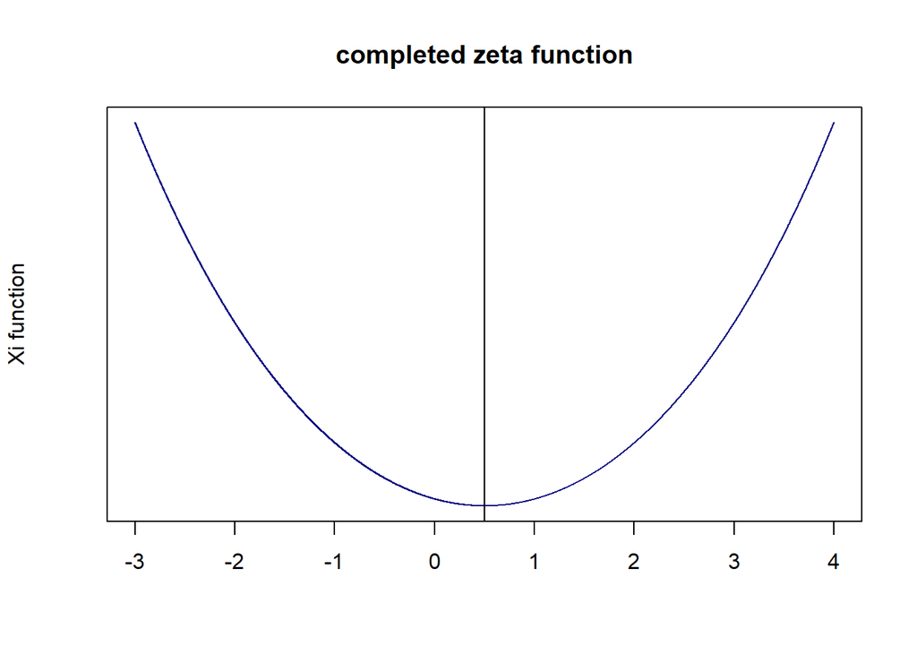

```r
library(VGAM)

x <- seq(-3,4,0.001)
xi <- 1/2 * x * (x - 1) * pi^(-x/2) * gamma(x/2) * zeta(x)

plot(x,xi, type='l', ylab='Xi function', xlab='',
     yaxt='n', col='navy',
     main='completed zeta function')
abline(v=1/2)
```

From [here](https://youtu.be/epnPu9mx738?si=Uj9i-ReC3Go8jNXx) and [here](https://en.wikipedia.org/wiki/Riemann_Xi_function):

$$\xi(z)=\frac 1 2 z(z - 1)\, \pi^{-\frac
z 2}\,\Gamma\left(\frac 1 2 z\right)\, \zeta(z)$$
for $\Re(z) >1.$

This function can be extended to all complex numbers, and

$$\xi(z) = \xi(1 -z)$$

It is used to analytically continue the zeta function.

The proof starts off with the gamma function:

$$\Gamma(1/2 z) = \int_0^\infty t^{\frac 1
2 z - 1}\, e^{-t}\,dt$$

We’ll proceed with the substitution

$$t= \pi n^2 \, u$$
and
$$dt= \pi n^2 \, du$$

Therefore,

$$\Gamma(1/2 z) = \int_0^\infty (\pi n^2
\, u)^{\frac 1 2 z - 1}\, e^{-\pi n^2 \, u}\,\pi n^2 \, du\\
= \int_0^\infty (\pi n^2)^{\frac 1 2 z} \, u^{\frac 1 2 z - 1}\, e^{-\pi
n^2 \, u} \, du$$

Rearranging,

$$\pi^{-\frac 1 2 z}\, \Gamma\left(\frac 1
2 z\right)\,n^{-z}=\int_0^\infty u^{\frac 1 2 z - 1}\, e^{-\pi n^2 \,
u} \, du$$

Summing on both sides

$$\sum_{n=1}^\infty \pi^{-\frac 1 2 z}\,
\Gamma\left(\frac 12 z\right)\,n^{-z} =
\sum_{n=1}^\infty\int_0^\infty u^{\frac 1 2 z - 1}\, e^{-\pi n^2 \, u}
\, du$$
or

$$\pi^{-\frac 1 2z}\, \Gamma\left(\frac 1
2 z \right)\,\zeta(z) = \sum_{n=1}^\infty \int_0^\infty u^{\frac 1 2 z
- 1}\, e^{-\pi n^2 \, u} \, du$$

Invoking the Fubini theorem

$$\pi^{-\frac 1 2 z}\, \Gamma\left(\frac
1 2 z\right)\,\zeta(z)= \int_0^\infty
\color{red}{\sum_{n=1}^\infty e^{-\pi n^2u}} \,u^{\frac 1 2 z - 1} \,
du$$

Defining
$$\omega(u) =
\sum_{n=1}^\infty e^{-\pi n^2u}$$
the connection can be established to the Jacobi Theta function:

$$\Theta(z)=\color{brown}{\sum_{n=-\infty}^\infty
e^{-\pi n^2 z}}$$

which has the property that

$$\Theta(z^{-1})=\sqrt z\;
\Theta(z)$$
for $\Re(z) > 1.$

Proof:

$$\Theta\left(z^{-1}\right) =
\sum_{n=-\infty}^\infty e^{-\pi n^2 z^{-1}}$$

Doing a Fourier expansion (Poisson summation),

$$\Theta(z^{-1}) = \sum_{n=-\infty}^\infty
\int_{-\infty}^\infty e^{-\pi t^2 z^{-1}}\, e^{-2\pi\, i\,
n\,t}\,dt$$

Doing a $u$-substitution with $t = \sqrt z\, u \implies dt = \sqrt z \,du,$

$$\Theta\left(z^{-1}\right) =
\sum_{n=-\infty}^\infty \sqrt z\int_{-\infty}^\infty e^{-\pi \, u^2
-2\pi\, i\, n\,\sqrt z \, u}\,du$$

Simplifying

$$\Theta\left(z^{-1}\right) =
\sum_{n=-\infty}^\infty \sqrt z\int_{-\infty}^\infty e^{-\pi \, (u +
i\,n\, \sqrt z)^2-n^2\,z \,\pi}\,du$$
Extracting out of the integral

$$\Theta\left(z^{-1}\right) =
\sum_{n=-\infty}^\infty \sqrt z e^{-n^2 \,z\,\pi}\,\int_{-\infty}^\infty
e^{-\pi \, (u + i\,n\, \sqrt z)^2}\,du$$

Defining $v= u + i\, n \, \sqrt z,$

$$\int_{-\infty}^\infty e^{-\pi \,
v^2}\,dv=\int_{-\infty}^\infty e^{-(\sqrt\pi \, v)^2}\,dv$$

Substituting $t=\sqrt \pi v\implies dt = \sqrt \pi dv$ and we get the Gaussian integral:

$$\frac 1 {\sqrt \pi}\int_{-\infty}^\infty
e^{-t^2}\,dt = \frac {\sqrt \pi} {\sqrt \pi}=1$$

Therefore

$$\Theta(z^{-1}) = \sum_{n=-\infty}^\infty
\sqrt z \, e^{-n^2 \,z\,\pi}=\sqrt z\, \sum_{n=-\infty}^\infty e^{-n^2
\,z\,\pi} =\sqrt z\, \Theta (z)\quad \square$$

Now we need to reconcile the limits of summation of $\omega(u)$ and $\Theta(z)$. We can split the limits of theta:

$$\Theta(z)=\color{brown}{\sum_{n=-\infty}^\infty
e^{-\pi n^2 z}} = \sum_{n=1}^\infty\ e^{-\pi\, n^2 \, z}+
\sum_{n=-\infty}^{-1}\ e^{-\pi\, n^2 \, z} + 1 \\
= \sum_{n=1}^\infty\ e^{-\pi\, n^2 \, z}+ \sum_{n=1}^{\infty}\ e^{-\pi\,
n^2 \, z} + 1$$

by symmetry given by the $n^2.$

Therefore,

$$\Theta(z)=2 \omega(z) + 1$$

Now,

$$\color{lime}{\omega\left(z^{-1}\right)}=\frac 1
2\,\left(\Theta(z^{-1}) - 1\right)\\
=\frac 1 2\,\left(\sqrt z\, \Theta(z) - 1\right)\\
=\frac 1 2\,\sqrt z\, \Theta(z)- \frac 1 2\\
= \frac 1 2 \, \sqrt z \, \left(2 \, \omega(z) + 1\right) - \frac 1 2\\
= \color{lime}{\sqrt z \, \omega(z) + \frac 1 2 \, \sqrt z - \frac 1
2}$$

Going back to the equation above,

$$\pi^{-\frac 1 2 z}\, \Gamma\left(\frac
1 2 z \right)\,\zeta(z)= \int_0^\infty
\color{red}{\sum_{n=1}^\infty e^{-\pi n^2u}} \,u^{\frac 1 2 z-1} \,
du\\
= \int_1^\infty \omega(u)\, u^{\frac 1 2 z - 1}du + \int_0^1 \omega(u)\,
u^{\frac 1 2 z - 1} du$$

Using the substitution, $v = u^{-1} \implies dv = -u^{-2}du$, and $-\frac 1{v^2} dv = du,$

$$\pi^{-\frac 1 2 z}\, \Gamma\left(\frac 1
2 z\right)\,\zeta(z) = \int_1^\infty \omega(u)\, u^{\frac 1 2 z - 1} du
+ \int_1^\infty v^{-2}\,\color{lime}{\omega(v^{-1})}\, v^{-\frac 1 2
z+1}dv$$

For the part in lime, we can use the identity derived above:

$$\pi^{-\frac 1 2 z}\, \Gamma\left(\frac 1
2 z\right)\,\zeta(z) = \int_1^\infty \omega(u)\, u^{\frac 1 2 z - 1} du
+ \int_1^\infty v^{-\frac 1 2 z - 1}\,\color{lime}{\left(\sqrt z \,
\omega(z) + \frac 1 2 \, \sqrt z - \frac 1 2\right)}\, dv\\
=\int_1^\infty \omega(u)\, u^{\frac 1 2 z - 1} du + \int_1^\infty
v^{-\frac 1 2 z -\frac 1 2}\,\omega(v)\,+ \frac 1 2\, v^{-\frac 1 2 z -
\frac 1 2}- \frac 1 2v^{-\frac 1 2 z - 1}\,dv\\
=\int_1^\infty \omega(u)\, u^{\frac 1 2 z - 1} du + \int_1^\infty
v^{-\frac 1 2 z - \frac 1 2}\,\omega(v)\,dv+\int_1^\infty \frac 1 2\,
v^{-\frac 1 2 z - \frac 1 2} - \frac 1 2 v^{-\frac 1 2 z - 1}\,dv\\
=\int_1^\infty \omega(u)\, u^{\frac 1 2 z - 1} du + \int_1^\infty
v^{-\frac 1 2 z - \frac 1 2}\,\omega(v)\,dv+\frac 1 {z(z -
1)}$$

To make the RHS equal to $\xi(z)=\frac 1 2 z(z-1)\, \pi^{-z/2}\,\Gamma\left(\frac 1 2 z\right)\, \zeta(z)$ we need to multiply both sides by $\frac 1 2 z(z-1).$ This will yield

$$\xi(z)= \frac 1 2 + \frac 1 2 z(z-1)
\left( \int_1^\infty \omega(u)\, u^{\frac 1 2 z-1} \, du + \int_1^\infty
v^{-\frac 1 2 z - \frac 1 2}\,\omega(v)\,dv\right)=\xi(1 -
z)$$

Try just plugging in

$$\xi(\color{gold}{1 - z})= \frac 1 2 +
\frac 1 2 (\color{gold}{1 - z})((\color{gold}{1 - z})-1) \left(
\int_1^\infty \omega(u)\, u^{\frac 1 2 (\color{gold}{1 - z})-1} \, du +
\int_1^\infty v^{-\frac 1 2 (\color{gold}{1 - z}) - \frac 1
2}\,\omega(v)\,dv\right)\\
=\frac 1 2 + \frac 1 2 (\color{gold}{1 - z})(\color{gold}{- z}) \left(
\int_1^\infty \omega(u)\, u^{\frac 1 2 (\color{gold}{1 - z})-1} \, du +
\int_1^\infty v^{-\frac 1 2 (\color{gold}{1 - z}) - \frac 1
2}\,\omega(v)\,dv\right)\\
=\frac 1 2 + \frac 1 2 (\color{gold}{z-1})(\color{gold}{ z}) \left(
\int_1^\infty \omega(u)\, u^{ \color{gold}{-\frac 1 2 - \frac z 2}} \,
du + \int_1^\infty v^{ \color{gold}{-1 +\frac z
2}}\,\omega(v)\,dv\right)\\
=\frac 1 2 + \frac 1 2 (\color{gold}{z-1})(\color{gold}{ z}) \left(
\int_1^\infty \omega(u)\, u^{ \color{gold}{-\frac 1 2 z - \frac 1 2}} \,
du + \int_1^\infty v^{ \color{gold}{\frac 1 2 z -
1}}\,\omega(v)\,dv\right)= \xi(z)$$

by symmetry of the dummy variables $u$ and $v$ in the integrals.

### Alternative functional equation:

Remembering the Xi function:

$$\xi(z)=\frac 1 2 z(z-1)\, \pi^{-\frac z
2}\,\Gamma\left(\frac 1 2 z\right)\, \zeta(z)$$

the zeta function can be expressed as

$$\zeta(z) = \frac{\xi(z)}{\frac 1 2
z(z-1)\, \pi^{-z/2}\,\Gamma\left(\frac 1 2 z\right)}$$

And $\zeta(1 - z)$ as

$$\zeta(1-z) = \frac{\xi(1-z)}{\frac 1 2
z(z-1)\, \pi^{-(1-z)/2}\,\Gamma\left(\frac 1 2 (1-z)\right)}$$
But in the previous section it became clear that $\xi(z) = \xi(1-z).$ Therefore

$$\zeta(1-z) = \frac{\frac 1 2 z(z-1)\,
\pi^{-z/2}\,\Gamma\left(\frac 1 2 z\right)\, \zeta(z)}{\frac 1 2
z(z-1)\, \pi^{-\frac{1-z}2}\,\Gamma\left(\frac 1 2 (1-z)\right)}=
\color{red}{\pi^{\frac 1 2 - z}\, \frac{\Gamma\left(\frac 1 2
z\right)}{\Gamma\left(\frac 1 2(1-z)\right)}}\zeta(z)$$

Two identities:

$$\Gamma(z) \, \Gamma(1-z) =
\frac{\pi}{\sin(\pi\,z)}$$

and

$$\Gamma(z) \, \Gamma\left(z+ \frac 1
2\right) = 2^{1-2z}\, \sqrt \pi \,\Gamma(2z)$$

So going back to the expression above in red,

$$\pi^{\frac 1 2-z}\,
\frac{\Gamma\left(\frac 1 2 z\right)}{\Gamma\left(\frac 1
2(1-z)\right)}=\pi^{\frac 1 2 - z}\, \frac{\Gamma\left(\frac 1 2
z\right)}{\Gamma\left(\frac 1 2(1-z)\right)}\frac{\Gamma\left(\frac 1 2
z + \frac 1 2\right)}{\Gamma\left(\frac 1 2 z + \frac 1
2\right)}$$

The numerator $\Gamma(1/2z)\, \Gamma(1/2 z + 1/2)$ matches the second equality above, whereas the denominator, i.e. $\Gamma(1/2(1-z))\,\Gamma(1/2 z + 1/2)$ matches the first equality because $1 - 1/2(1-z) = 1/2z + 1/2)$. Therefore,

$$\pi^{\frac 1 2 - z}\,
\frac{\Gamma\left(\frac 1 2 z\right)}{\Gamma\left(\frac 1
2(1-z)\right)}=\pi^{\frac 1 2 - z}\,\frac{2^{1 - z\,\sqrt\pi}\,
\Gamma(z)}{\frac{\pi}{\sin\left(\pi\left(\frac 1 2 - \frac 1 2
z\right)\right)}}= \pi^{-z}\, 2^{1-z}\,\sin\left(\frac{\pi}2 - \pi \frac
z 2\right)\, \Gamma(z)$$

Therefore,

$$\zeta(1-z)= \pi^{-z}\, 2^{1 -
z}\,\sin\left(\frac{\pi}2 - \pi \frac z 2 \right)\, \Gamma(z)\,
\zeta(z)$$

Since $\sin(\pi/2 -z) = \cos(z)$

we finally arrive at the following different way of writing down the **FUNCTIONAL EQUATION:**

$$\bbox[7px,border:2px solid
red]{\zeta(1-z)= \pi^{-z}\, 2^{1-z}\,\cos\left(\frac{\pi z}{2} \right)\,
\Gamma(z)\, \zeta(z)}$$

In the opposite direction [(see here)](https://math.stackexchange.com/a/437886/152225):

$$\bbox[7px,border:2px solid
blue]{\zeta(z)=2^{z}\pi^{z-1}\sin\left(\frac{\pi
z}{2}\right)\Gamma(1-z)\zeta(1-z)}$$

How to go from red to blue?

$$\zeta(z) = \frac{\zeta(1 -
z)}{\pi^{-z}\, 2^{1-z}\,\color{green}{\cos\left(\frac{\pi z}{2}
\right)}\, \Gamma(z)}=\frac{\zeta(1-z)\,2^z\,
\pi^z\,\color{green}{2\sin\left(\frac{\pi
z}2\right)}}{2\,\color{green}{\sin(\pi
z)}\,\Gamma(z)}=\frac{\zeta(1-z)\,2^z\, \pi^z\,\sin\left(\frac{\pi
z}2\right)}{\sin(\pi z)\,\Gamma(z)}$$

The trigonometric changes is because $2 \, \sin(\alpha/2)\,\cos(\alpha/2)=\sin(\alpha)$. Since $\Gamma(z) \, \Gamma(1-z) = \frac{\pi}{\sin(\pi\,z)}$, it follows that
$$\Gamma(1-z) = \frac{\pi}{\sin(\pi\,z)\, \Gamma(z)
}$$

Therefore the previous expression can be simplified as:

$$\zeta(z) = \zeta(1-z) \, 2^z
\,\pi^{z-1}\,\sin\left(\frac{\pi z}2\right)\, \Gamma(1-z) \quad
\square$$

### Functional Equation with the Dirichlet Eta Function:

From [here](https://youtu.be/FKzyE6d1zWI?si=-Zfqa9jfLC_gplcF):

The eta function is

$$\eta(s)=\sum_{k=1}^\infty
\frac{(-1)^{k - 1}}{k^s}$$
a kind of alternating zeta function that converges for $\Re(s) > 0$.

This can be split into odd and even terms:

$$\eta(s) = \sum_{j=1}^\infty \frac1{(2j -
1)^s} - \sum_{i=1}^\infty \frac 1{(2i)^s}$$

Likewise the zeta function can be split into odd and even terms:

$$\zeta(s) = \sum_{j=1}^\infty \frac1{(2j
- 1)^s} + \sum_{i=1}^\infty \frac 1{(2i)^s}$$

Therefore

$$\zeta(s) - \eta(s) = 2\,
\sum_{k=1}^\infty \frac 1 {(2k)^s}= 2^{1-s}\zeta(s)$$

or

$$\bbox[7px,border:2px solid
red]{\zeta(s)= \frac 1{1 - 2^{1-s}}\,\eta(s)}$$

[Home Page](http://rinterested.github.io/statistics/index.html)

**NOTE: These are tentative notes on different topics for personal use - expect mistakes and misunderstandings.**